# $\color{Maroon}{CA4-PART2}$

## $\color{Olive}{\bullet \hspace{3pt} Optimizer \hspace{3pt} impact:}$

Momentum is an extension to the gradient descent optimization algorithm, often referred to as gradient descent with momentum. It is designed to accelerate the optimization process, or to improve the capability of the optimization algorithm. The general idea behind this technique is because at gentle slope gradient is very small so update becomes slow.

Momentum involves adding an additional hyperparameter that controls the amount of history (momentum) to include in the update equation, i.e. the step to a new point in the search space. The value for the hyperparameter is defined in the range 0.0 to 1.0 and often has a value close to 1.0, such as 0.8, 0.9, or 0.99. A momentum of 0.0 is the same as gradient descent without momentum.

Gradient descent update **without** momentum: change_x = step_size * f'(x)

Gradient descent update **with** momentum: change_x(t) = step_size *f'(x(t-1)) + momentum* change_x(t-1)

In short, the momentum algorithm accumulates an exponentially decaying moving average of past gradients and continues to move in their direction.

```python
tf.keras.optimizers.SGD(
    learning_rate=0.01, momentum=0.5, nesterov=False, name='SGD'
)
model.compile(optimizer='SGD',
              loss='categorical_crossentropy',
              metrics=['accuracy'])
```

```python
log = model.fit(x=train_ds_processed, epochs=10, validation_data=val_ds_processed)
```

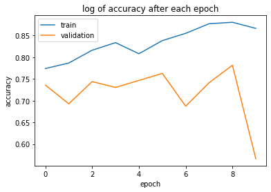

```python
plt.plot(log.history['accuracy'])
plt.plot(log.history['val_accuracy'])
plt.title('log of accuracy after each epoch')
plt.ylabel('accuracy')
plt.xlabel('epoch')
plt.legend(['train', 'validation'], loc='upper left')
plt.show()
```

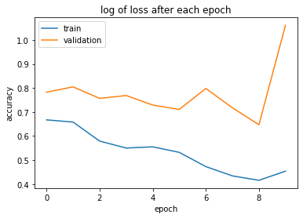

```python
plt.plot(log.history['loss'])
plt.plot(log.history['val_loss'])
plt.title('log of loss after each epoch')
plt.ylabel('accuracy')
plt.xlabel('epoch')
plt.legend(['train', 'validation'], loc='upper left')
plt.show()
```

```python
y_pred = model.predict(val_ds_processed, verbose = 1)
y_pred_res = np.argmax(y_pred, axis = 1)

y_true = np.array(val_ds_processed.labels)

print(classification_report(y_true, y_pred_res))
```

```
              precision    recall  f1-score   support

           0       0.94      0.31      0.47       100
           1       0.97      0.37      0.53        90
           2       0.73      0.70      0.72        97
           3       0.37      0.93      0.53        84

    accuracy                           0.57       371
   macro avg       0.75      0.58      0.56       371
weighted avg       0.76      0.57      0.56       371
```

```python
tf.keras.optimizers.SGD(
    learning_rate=0.01, momentum=0.9, nesterov=False, name='SGD'
)
model.compile(optimizer='SGD',
              loss='categorical_crossentropy',
              metrics=['accuracy'])
```

```python
log = model.fit(x=train_ds_processed, epochs=10, validation_data=val_ds_processed)
```

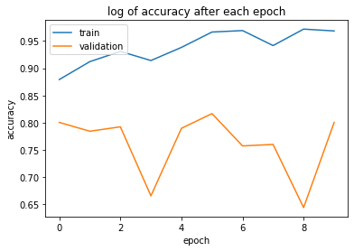

```python
plt.plot(log.history['accuracy'])
plt.plot(log.history['val_accuracy'])
plt.title('log of accuracy after each epoch')
plt.ylabel('accuracy')
plt.xlabel('epoch')
plt.legend(['train', 'validation'], loc='upper left')
plt.show()
```

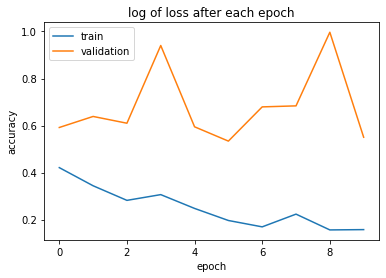

```python
plt.plot(log.history['loss'])
plt.plot(log.history['val_loss'])
plt.title('log of loss after each epoch')
plt.ylabel('accuracy')
plt.xlabel('epoch')
plt.legend(['train', 'validation'], loc='upper left')
plt.show()
```

```python
y_pred = model.predict(val_ds_processed, verbose = 1)
y_pred_res = np.argmax(y_pred, axis = 1)

y_true = np.array(val_ds_processed.labels)

print(classification_report(y_true, y_pred_res))
```

```
              precision    recall  f1-score   support

           0       0.74      0.81      0.77       100
           1       0.86      0.82      0.84        90
           2       0.77      0.80      0.79        97
           3       0.86      0.76      0.81        84

    accuracy                           0.80       371
   macro avg       0.81      0.80      0.80       371
weighted avg       0.80      0.80      0.80       371
```

Note that while bigger momentum might seem like a good choice, by choosing greater values, we are averaging over bigger numbers of points and therefore taking bigger steps at each run. Typically, a value between 0.9 and 0.99 should be an appropriate choice.

$\color{darkgoldenrod}{Adam \hspace{3pt} Optimizer}$

```python
model.compile(optimizer='adam',
              loss='categorical_crossentropy',
              metrics=['accuracy'])
```

```python
log = model.fit(x=train_ds_processed, epochs=10, validation_data=val_ds_processed)
```

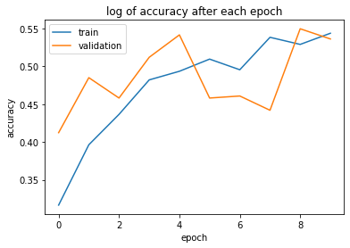

```python
plt.plot(log.history['accuracy'])
plt.plot(log.history['val_accuracy'])
plt.title('log of accuracy after each epoch')
plt.ylabel('accuracy')
plt.xlabel('epoch')
plt.legend(['train', 'validation'], loc='upper left')
plt.show()
```

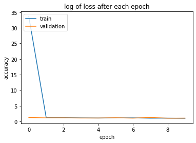

```python
plt.plot(log.history['loss'])
plt.plot(log.history['val_loss'])
plt.title('log of loss after each epoch')
plt.ylabel('accuracy')
plt.xlabel('epoch')
plt.legend(['train', 'validation'], loc='upper left')
plt.show()
```

```python
y_pred = model.predict(val_ds_processed, verbose = 1)
y_pred_res = np.argmax(y_pred, axis = 1)

y_true = np.array(val_ds_processed.labels)

print(classification_report(y_true, y_pred_res))
```

```
              precision    recall  f1-score   support

           0       0.72      0.31      0.43       100
           1       0.54      0.69      0.60        90
           2       0.66      0.32      0.43        97
           3       0.45      0.89      0.60        84

    accuracy                           0.54       371
   macro avg       0.59      0.55      0.52       371
weighted avg       0.60      0.54      0.51       371
```

We can see that adam optimizer has worked rather well for our model. However, compared to our original SGD optimizer without any momentum, adam optimizer has lower accuracy.

## $\color{Olive}{\bullet \hspace{3pt} Epoch \hspace{3pt} impact:}$

Our main goal is to get good performance on our test data, this usually means taking more than one pass over the training data (it's typical that gradient descent doesn't reach a minimum after the first epoch).

Now if performance on the training set improves while the performance on the hold-out data gets worse, overfitting happens, so prolonged training can cause overfitting. Training a model enough just means that the model gets better.

Generally, we test our training data with different epoch sizes so that we can find the perfect size for our network in such a way that we reach better perfomance and overfitting doesn't happen.

Note that it is a good practice to check multiple rounds of update (epochs) to estimate models, and this isn't limited to neural networks. Infact, this is common to all iterative model estimation procedures like logistic regression, SVM and gradient boosting.

$\color{darkgoldenrod}{epoch = 20}$

```python
model.compile(optimizer='adam',
              loss='categorical_crossentropy',
              metrics=['accuracy'])
```

```python
log = model.fit(x=train_ds_processed, epochs=20, validation_data=val_ds_processed)
```

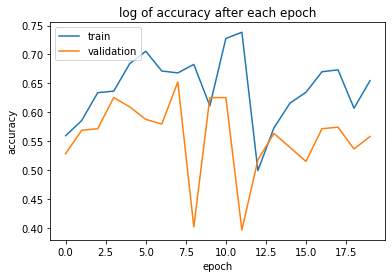

```python
plt.plot(log.history['accuracy'])
plt.plot(log.history['val_accuracy'])
plt.title('log of accuracy after each epoch')
plt.ylabel('accuracy')
plt.xlabel('epoch')
plt.legend(['train', 'validation'], loc='upper left')
plt.show()
```

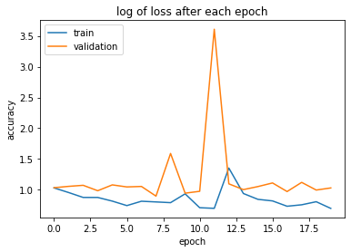

```python
plt.plot(log.history['loss'])
plt.plot(log.history['val_loss'])
plt.title('log of loss after each epoch')
plt.ylabel('accuracy')
plt.xlabel('epoch')
plt.legend(['train', 'validation'], loc='upper left')
plt.show()
```

```python
y_pred = model.predict(val_ds_processed, verbose = 1)
y_pred_res = np.argmax(y_pred, axis = 1)

y_true = np.array(val_ds_processed.labels)

print(classification_report(y_true, y_pred_res))
```

```
              precision    recall  f1-score   support

           0       0.56      0.72      0.63       100
           1       0.46      0.84      0.60        90
           2       0.68      0.15      0.25        97
           3       0.80      0.52      0.63        84

    accuracy                           0.56       371
   macro avg       0.63      0.56      0.53       371
weighted avg       0.62      0.56      0.52       371
```

We observe that accuracy has increased slightly compared to when epochs number was 10.

We can run our design for more epochs and evaluate our model to see where overfitting happens.

```python
log = model.fit(x=train_ds_processed, epochs=30, validation_data=val_ds_processed)
```

```python
_, train_acc = model.evaluate(train_ds_processed)
_, val_acc = model.evaluate(val_ds_processed)
print('Train: %.3f, Val: %.3f' % (train_acc, val_acc))
```

```
Train: 0.776, Val: 0.593
```

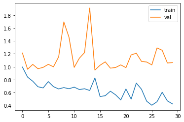

```python
plt.plot(log.history['loss'], label='train')
plt.plot(log.history['val_loss'], label='val')
plt.legend()
plt.show()
```

By the above plot, we can observe that the minimum loss for our validation data has occurred somewhere around 13 epochs.

We can also change our design so that it stops whenever overfitting happens. To do so, we use early stopping.

```python
from keras.callbacks import ModelCheckpoint, EarlyStopping
es = EarlyStopping(monitor='val_loss', mode='min', verbose=1, patience=10)

log = model.fit(x=train_ds_processed, epochs=30, validation_data=val_ds_processed, callbacks=[es])
```

```
Epoch 00029: early stopping
```

```python
_, train_acc = model.evaluate(train_ds_processed, verbose=0)
_, val_acc = model.evaluate(val_ds_processed, verbose=0)
print('Train: %.3f, Val: %.3f' % (train_acc, val_acc))
```

```
Train: 0.752, Val: 0.604
```

We can see that we've reached a higher accuracy for validation data using early stopping.

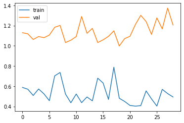

```python
plt.plot(log.history['loss'], label='train')
plt.plot(log.history['val_loss'], label='val')
plt.legend()
plt.show()
```

We can observe that using more epochs doesn't always mean a better performance. By using early stopping and perhaps model checkpoints (like this $\href{https://machinelearningmastery.com/how-to-stop-training-deep-neural-networks-at-the-right-time-using-early-stopping/ }{link}$) we can run our model for different number of epochs and save the best version where overfitting doesn't happen and use it later for our test data.

## $\color{Olive}{\bullet \hspace{3pt} Loss \hspace{3pt} impact:}$

In this part we train our model using MSE loss function.

```python
model.compile(optimizer='adam',
              loss='mean_squared_error',
              metrics=['accuracy'])
```

```python
log = model.fit(x=train_ds_processed, epochs=10, validation_data=val_ds_processed)
```

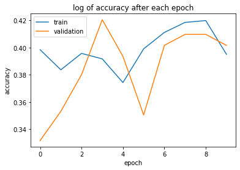

```python
plt.plot(log.history['accuracy'])
plt.plot(log.history['val_accuracy'])
plt.title('log of accuracy after each epoch')
plt.ylabel('accuracy')
plt.xlabel('epoch')
plt.legend(['train', 'validation'], loc='upper left')
plt.show()
```

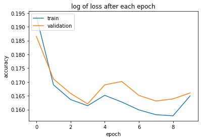

```python
plt.plot(log.history['loss'])
plt.plot(log.history['val_loss'])
plt.title('log of loss after each epoch')
plt.ylabel('accuracy')
plt.xlabel('epoch')
plt.legend(['train', 'validation'], loc='upper left')
plt.show()
```

```python
y_pred = model.predict(val_ds_processed, verbose = 1)
y_pred_res = np.argmax(y_pred, axis = 1)

y_true = np.array(val_ds_processed.labels)

print(classification_report(y_true, y_pred_res))
```

```
              precision    recall  f1-score   support

           0       0.97      0.30      0.46       100
           1       0.30      0.98      0.46        90
           2       0.66      0.32      0.43        97
           3       0.00      0.00      0.00        84

    accuracy                           0.40       371
   macro avg       0.48      0.40      0.34       371
weighted avg       0.51      0.40      0.35       371
```

We can see that the result isn't as promising as it is for the categorical_crossentropy loss function.

Note that there are two main reasons why MSE isn't a good loss function for classification problems:

1. Using MSE means that we assume that the underlying data has been generated from a normal distribution. In Bayesian terms this means we assume a Gaussian prior. While in reality, a dataset that can be classified into two categories is not from a normal distribution but a Bernoulli distribution. If we use maximum likelihood estimation, assuming that the data is from a normal distribution, we get the MSE as a Cost function for optimizing our model.
2. The MSE function is non-convex for binary classification. In simple terms, if a binary classification model is trained with MSE Cost function, it is not guaranteed to minimize the Cost function. This is because MSE function expects real-valued inputs in range($-\infty, \infty$), while binary classification models output probabilities in range(0,1) through the sigmoid/logistic function.

Further reading: $\href{https://towardsdatascience.com/why-using-mean-squared-error-mse-cost-function-for-binary-classification-is-a-bad-idea-933089e90df7#:~:text=There%20are%20two%20reasons%20why,choice%20for%20binary%20classification%20problems%3A&text=When%20the%20MSE%20function%20is,the%20target%20value%20(y)}{link}$

## $\color{Olive}{\bullet \hspace{3pt} Regularization \hspace{3pt} impact:}$

$\color{darkgoldenrod}{l2 \hspace{3pt} regularizer}$

Weight regularization provides an approach to reduce the overfitting of a deep learning neural network model on the training data and improve the performance of the model on new data, such as the validation set. Here we inspect the impact of l2 regulizer which takes the sum of the squared weights into account.

```python
model = tf.keras.Sequential([
    tf.keras.layers.Flatten(input_shape=(img_height, img_width, 1)),
    tf.keras.layers.Dense(8192, activation='relu', kernel_regularizer=tf.keras.regularizers.l2(0.0001)),
    tf.keras.layers.Dense(4096, activation='relu', kernel_regularizer=tf.keras.regularizers.l2(0.0001)),
    tf.keras.layers.Dense(4, activation='softmax', kernel_regularizer=tf.keras.regularizers.l2(0.0001))
])
```

```python
model.compile(optimizer='adam',
              loss='categorical_crossentropy',
              metrics=['accuracy'])
```

```python
log = model.fit(x=train_ds_processed, epochs=10, validation_data=val_ds_processed)
```

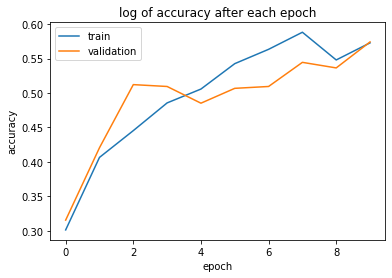

```python
plt.plot(log.history['accuracy'])
plt.plot(log.history['val_accuracy'])
plt.title('log of accuracy after each epoch')
plt.ylabel('accuracy')
plt.xlabel('epoch')
plt.legend(['train', 'validation'], loc='upper left')
plt.show()
```

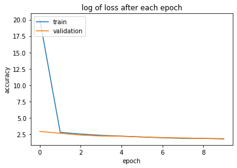

```python
plt.plot(log.history['loss'])
plt.plot(log.history['val_loss'])
plt.title('log of loss after each epoch')
plt.ylabel('accuracy')
plt.xlabel('epoch')
plt.legend(['train', 'validation'], loc='upper left')
plt.show()
```

```python
y_pred = model.predict(val_ds_processed, verbose = 1)
y_pred_res = np.argmax(y_pred, axis = 1)

y_true = np.array(val_ds_processed.labels)

print(classification_report(y_true, y_pred_res))
```

```
              precision    recall  f1-score   support

           0       0.76      0.32      0.45       100
           1       0.72      0.53      0.61        90
           2       0.49      0.71      0.58        97
           3       0.53      0.76      0.63        84

    accuracy                           0.57       371
   macro avg       0.62      0.58      0.57       371
weighted avg       0.63      0.57      0.56       371
```

We can see that although loss and val_loss have increased significantly, l2 regularizer is helping our model achieve higher accuracy in each epoch.

$\color{darkgoldenrod}{Dropout}$

Dropout is a regularization method that approximates training a large number of neural networks with different architectures in parallel.

During training, some number of layer outputs are randomly ignored or “dropped out.” This has the effect of making the layer look-like and be treated-like a layer with a different number of nodes and connectivity to the prior layer. In effect, each update to a layer during training is performed with a different “view” of the configured layer.

Dropout has the effect of making the training process noisy, forcing nodes within a layer to probabilistically take on more or less responsibility for the inputs.

```python
model = tf.keras.Sequential([
    tf.keras.layers.Flatten(input_shape=(img_height, img_width, 1)),
    tf.keras.layers.Dense(8192, activation='relu'),
    tf.keras.layers.Dropout(0.1),
    tf.keras.layers.Dense(4096, activation='relu'),
    tf.keras.layers.Dropout(0.1),
    tf.keras.layers.Dense(4, activation='softmax'),
    tf.keras.layers.Dropout(0.1)
])
```

```python
model.compile(optimizer='adam',
              loss='categorical_crossentropy',
              metrics=['accuracy'])
```

```python
log = model.fit(x=train_ds_processed, epochs=10, validation_data=val_ds_processed)
```

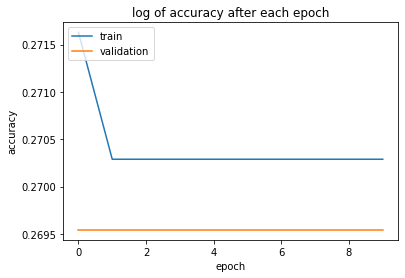

```python
plt.plot(log.history['accuracy'])
plt.plot(log.history['val_accuracy'])
plt.title('log of accuracy after each epoch')
plt.ylabel('accuracy')
plt.xlabel('epoch')
plt.legend(['train', 'validation'], loc='upper left')
plt.show()
```

[figure not shown]

```python
plt.plot(log.history['loss'])
plt.plot(log.history['val_loss'])
plt.title('log of loss after each epoch')
plt.ylabel('accuracy')
plt.xlabel('epoch')
plt.legend(['train', 'validation'], loc='upper left')
plt.show()
```

```python
y_pred = model.predict(val_ds_processed, verbose = 1)
y_pred_res = np.argmax(y_pred, axis = 1)

y_true = np.array(val_ds_processed.labels)

print(classification_report(y_true, y_pred_res))
```

```
              precision    recall  f1-score   support

           0       0.27      1.00      0.42       100
           1       0.00      0.00      0.00        90
           2       0.00      0.00      0.00        97
           3       0.00      0.00      0.00        84

    accuracy                           0.27       371
   macro avg       0.07      0.25      0.11       371
weighted avg       0.07      0.27      0.11       371
```

## $\color{crimson}{Final \hspace{3pt} Model}$

The following model showed to be accurate enough as well as fast to compile.

```python
model = tf.keras.Sequential([
    tf.keras.layers.Flatten(input_shape=(img_height, img_width, 1)),
    tf.keras.layers.Dense(8192, activation='relu'),
    tf.keras.layers.Dense(4096, activation='relu'),
    tf.keras.layers.Dense(4, activation='softmax')
])
tf.keras.optimizers.SGD(
    learning_rate=0.01, momentum=0.9, nesterov=False, name='SGD'
)
model.compile(optimizer='SGD',
              loss='categorical_crossentropy',
              metrics=['accuracy'])
```

```python
log = model.fit(x=train_ds_processed, epochs=10, validation_data=val_ds_processed)
```

```python
y_pred = model.predict(test_ds_processed, verbose = 1)
y_pred_res = np.argmax(y_pred, axis = 1)

y_true = np.array(test_ds_processed.labels)

print(classification_report(y_true, y_pred_res))
```

```
              precision    recall  f1-score   support

           0       0.69      0.56      0.62       211
           1       0.89      0.54      0.67       192
           2       0.66      0.82      0.73       206
           3       0.58      0.79      0.67       187

    accuracy                           0.68       796
   macro avg       0.71      0.68      0.67       796
weighted avg       0.71      0.68      0.67       796
```